# Outcrossing Populations

## Draw_map2

Drawing map builded with only recombinations informations

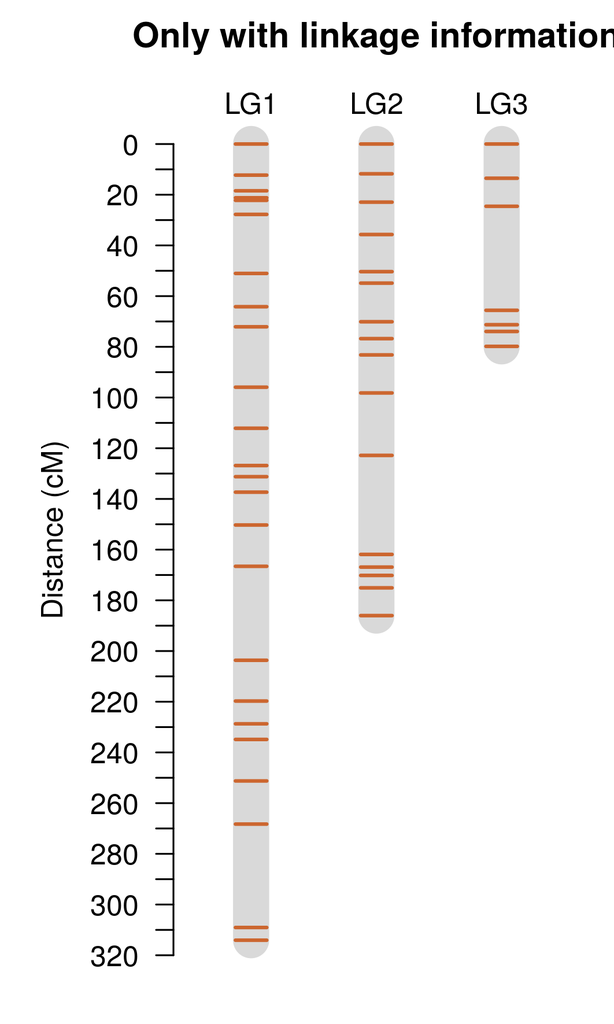

```r
draw_map2(LG1_final, LG2_final, LG3_final, main = "Only with linkage information",
          group.names = c("LG1", "LG2", "LG3"))
```

Drawing map builded with reference genome and recombinations informations

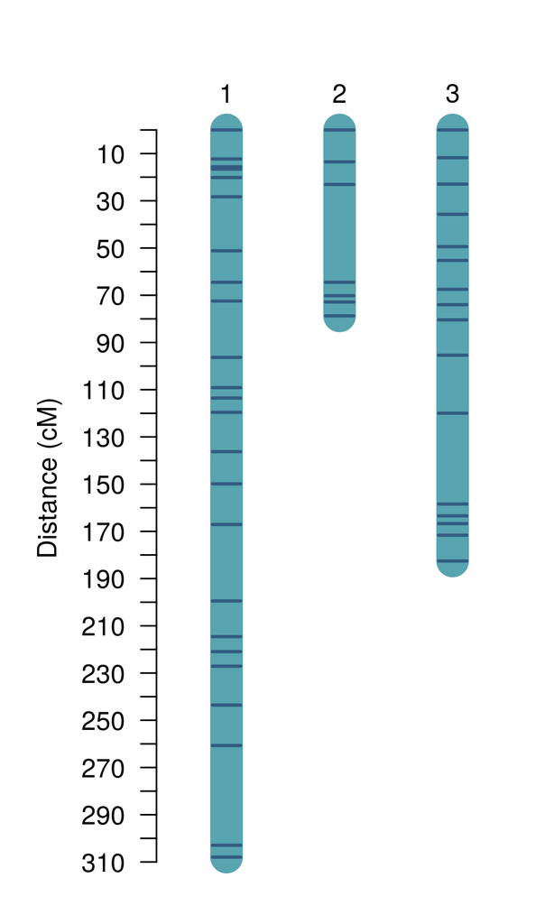

```r
draw_map2(CHR1_final, CHR2_final, CHR3_final, output= "map_ref.pdf",
          col.group = "#58A4B0",
          col.mark= "#335C81")
```

With the argument `tag`, we can highlight some markers with other color. The arguments `col.group`, `col.mark` and `col.tag` can be changed to personalize the color of the groups, the markers, and the highlighted markers, respectively.

We also can draw a maps comparing corresponding linkage groups in each strategy:

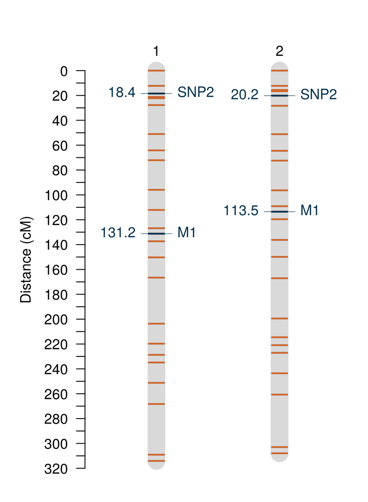

```r
draw_map2(LG1_final, CHR1_final, output = "map_comp.pdf", tag = c("M1","SNP2"))
```

When defining marker names in `tag` argument, all markers with these name will be highlighted no matter in which group it/they is/are.

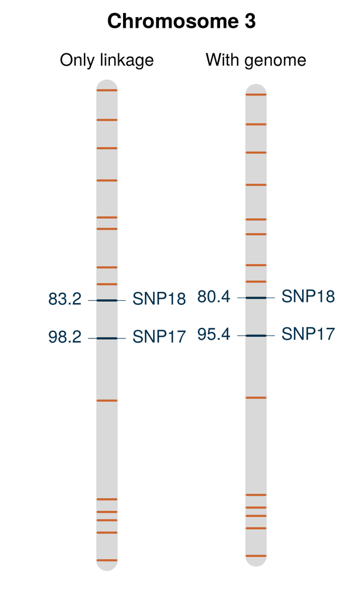

```r
draw_map2(LG2_final, CHR3_final, tag= c("SNP17", "SNP18", "M29"), main = "Chromosome 3",
          group.names = c("Only linkage", "With genome"), centered = TRUE, output = "map_comp2.pdf")
```

# Map estimation for an arbitrary order

If, for any reason, one wants to estimate parameters for a given linkage map (*e.g.*, for other orders on published papers), it is possible to define a sequence and use the `map` function. For example, for markers `M30`, `M12`, `M3`, `M14` and `M2`, in this order, use

```r
any_seq <- make_seq(twopts, c(30, 12, 3, 14, 2))
(any_seq_map <- map(any_seq))
```

```
##
## Printing map:
##
## Markers           Position           Parent 1       Parent 2
##
## 30 M30                0.00           a |  | b       a |  | b
## 12 M12                1.00           b |  | a       c |  | a
##  3 M3                20.57           o |  | a       o |  | o
## 14 M14               33.63           a |  | o       b |  | o
##  2 M2                41.70           o |  | o       o |  | a
##
## 5 markers            log-likelihood: -320.9012
```

**NOTE**: (new!) If your sequence has many markers (more than 60), we suggest to speed up `map` using BatchMap parallelization approach. See section `Speed up analysis with parallelization` for more information.

**Warning**: If you find an error message like:

```
Error in as_mapper(.f, ...) : argument ".f" is missing, with no default
```

It’s because the `map` function has a very common name and you can have in your environment other function with the same name. In the case of the pointed error, R is using `map` function from `purrr` package instead of `OneMap`, to solve this, simple specify that you want `OneMap` function with `::` command from `stringr` package::

```r
library(stringr)
(any_seq_map <- onemap::map(any_seq))
```

This is a subset of the first linkage group. When used this way, the `map` function searches for the best combination of phases between markers and prints the results.

(new!)

**Warning**: It is not our case in this example, but, sometimes, it can happen that some markers in your sequence doesn’t reach the `OneMap` linkage criteria when linkage are estimated by HMM multipoint approach using `map`, it will produce an error like this:

```
ERROR: The linkage between markers 1 and 2 did not reach the OneMap default criteria. They are probably segregating independently
```

You can evaluate the marker manually, or you can remove them automatically using `map` argument `rm_unlinked = TRUE`. Doing this, the `map` function will return a vector with marker numbers excluding the problematic marker, then, you can repeat the process without the marker, using `make_seq` to create a new sequence and repeat the `map`. You can also do it automatically using the `map_avoid_unlinked` function:

```r
LG2_test_map <- map_avoid_unlinked(input.seq = any_seq)
```

Using this, if `map` finds a problematic marker, it will print a warning pointing the marker number which was removed and will automatically repeat the analysis without it.

Furthermore, a sequence can also have user-defined linkage phases. The next example shows (incorrect) phases used for the same order of markers:

```r
any_seq <- make_seq(twopts, c(30, 12, 3, 14, 2), phase = c(4, 1, 4, 3))
(any_seq_map <- map(any_seq))
```

If one needs to add or drop markers from a predefined sequence, functions `add_marker` and `drop_marker` can be used. For example, to add markers 4 to 8 to `any_seq`.

```r
(any_seq <- add_marker(any_seq, 4:8))
```

```
##
## Number of markers: 10
## Markers in the sequence:
## M30 M12 M3 M14 M2 M4 M5 M6 M7 M8
##
## Parameters not estimated.
```

Removing markers 3, 4, 5, 12 and 30 from `any_seq`:

```r
(any_seq <- drop_marker(any_seq, c(3, 4, 5, 12, 30)))
```

```
##
## Number of markers: 5
## Markers in the sequence:
## M14 M2 M6 M7 M8
##
## Parameters not estimated.
```

After that, the map needs to be re-estimated.

# Speed up analysis with parallelization (new!)

**Warning**: By now, only available for Unix-like operating systems and for outcrossing and f2 intercross populations.

As already mentioned, `OneMap` uses HMM multipoint approach to estimate genetic distances, a very robust method, but it can take time to run if you have many markers. In 2017, Schiffthaler et. al release an `OneMap` fork with modifications in CRAN and in github with the possibility of parallelize the HMM chain dividing markers in batches and use different cores for each phase. Their approach speed up our HMM and keeps the genetic distances estimation quality. It allows to divide the job in maximum four cores according with the four possible phases for outcrossing mapping populations. We add this parallelized approach to the functions: `map`, `mds_onemap`, `seriation`, `rcd`, `record` and `ug`. For better efficiency it is important that batches are composed by 50 markers or more, therefore, this approach is only recommended for linkage groups with many markers.

Here we will show an example how to use the BatchMap approach in some functions that requires HMM. For this, we will simulate a group with 294 markers (we don’t want this vignette takes too much time to run, but usually maps with markers from high-throughput technologies result larger groups). Before start, you can see the time spent for each approach in this example:

|  | Without parallelization (h) | With parallelization (h) |
| --- | --- | --- |
| rcd | 0.6700558 | 0.1612458 |
| record_map | 1.4368436 | 0.2907308 |
| ug_map | 0.7145778 | 0.1884214 |
| mds_onemap | 1.0643083 | 0.2827314 |
| map | 2.0994486 | 0.6107456 |

Now, let’s simulate the mapping population and markers.

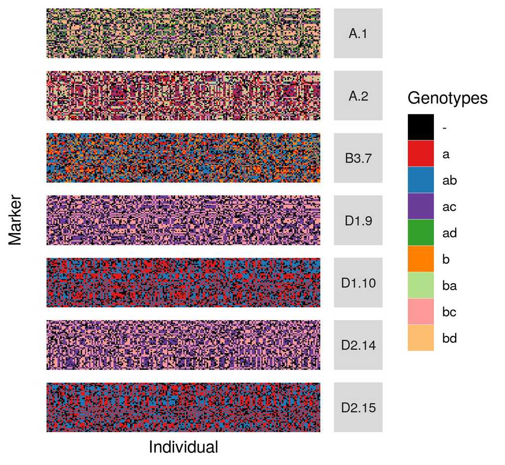

```r
run_pedsim(chromosome = "Chr1", n.marker = 294, tot.size.cm = 100, centromere = 50,
           n.ind = 200, mk.types = c("A1", "A2", "B3.7", "D1.9", "D1.10", "D2.14", "D2.15"),
           n.types = rep(42,7), pop = "F1", path.pedsim = "./",
           name.mapfile = "mapfile.txt", name.founderfile="founderfile.gen",
           name.chromfile="sim.chrom", name.parfile="sim.par",
           name.out="simParall_out")

# Do the conversion

pedsim2raw(cross="outcross", genofile = "simParall_out_genotypes.dat",
           parent1 = "P1", parent2 = "P2", out.file = "simParall_out.raw",
           miss.perc = 25)

# Import to R environment as onemap object

simParallel <- read_onemap("simParall_out.raw")
plot(simParallel, all=FALSE)
```

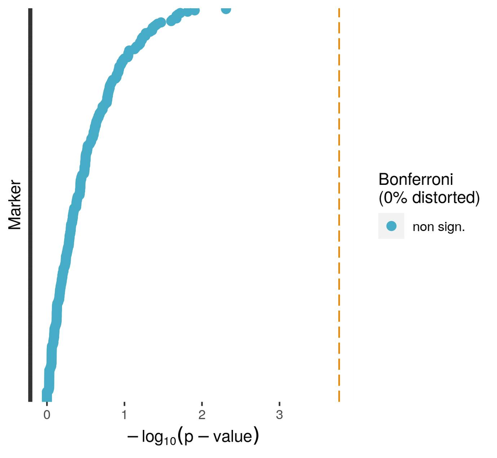

```r
# Calculates two-points recombination fractions
twopts <- rf_2pts(simParallel)

seq_all <- make_seq(twopts, "all")

# There are no redundant markers
find_bins(simParallel)

# There are no distorted markers
p <- plot(test_segregation(simParallel))
```

To prepare the data with defined bach size we use function `pick_batch_sizes`. It selects a batch size that splits the data into even groups. Argument `size` defines the batch size next to which an optimum size will be searched. `overlap` defines the number of markers that overlap between present batch and next. This is used because pre-defined phases at these overlap markers in present batch are used to start the HMM in the next batch. The `around` argument defines how much the function can vary around the defined number in `size` to search for the optimum batch size.

Some aspects should be considered to define these arguments, because if the batch size were set too high, there would be less gain in execution time. If the overlap size would be too small, phases would be incorrectly estimated and large gaps would appear in the map, inflating its size. In practise, these values will depend on many factors such as population size, marker quality and species. BatchMap authors recommended to try several configurations on a subset of data and select the best performing one.

```r
batch_size <- pick_batch_sizes(input.seq = seq_all,
                               size = 80,
                               overlap = 30,
                               around = 10)

batch_size
```

## Speed up two-points ordering approaches

To use parallelized approach you just need to include the arguments when using the functions:

```r
# Without parallelization
rcd_map <- rcd(input.seq = seq_all)

# With parallelization
rcd_map_par <- rcd(input.seq = seq_all,
                   phase_cores = 4,
                   size = batch_size,
                   overlap = 30)
```

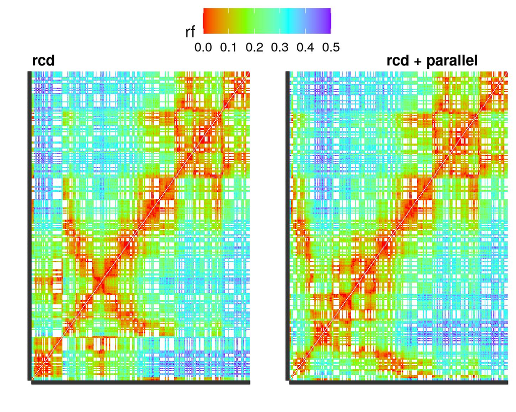

```r
# Without parallelization
record_map <- record(input.seq = seq_all)

# With parallelization
record_map_par <- record(input.seq = seq_all,
                         phase_cores = 4,
                         size = batch_size,
                         overlap = 30)
```

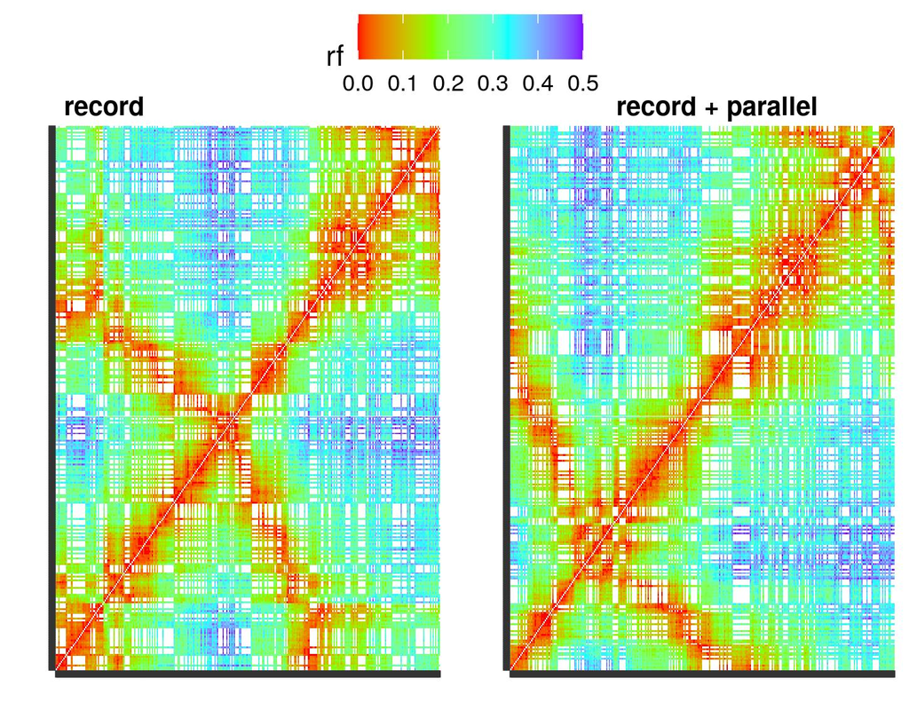

```r
# Without parallelization
ug_map <- ug(input.seq = seq_all)

# With parallelization
ug_map_par <- ug(input.seq = seq_all,
                 phase_cores = 4,
                 size = batch_size,
                 overlap = 30)
```

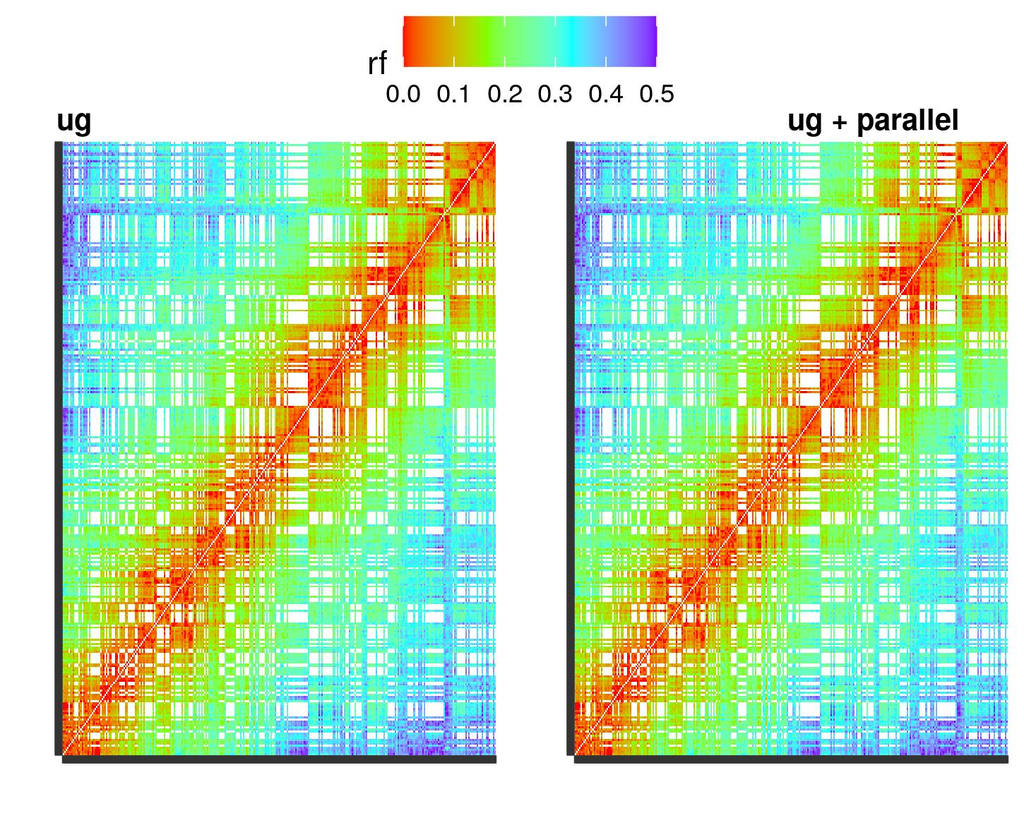

## Speed up mds_onemap

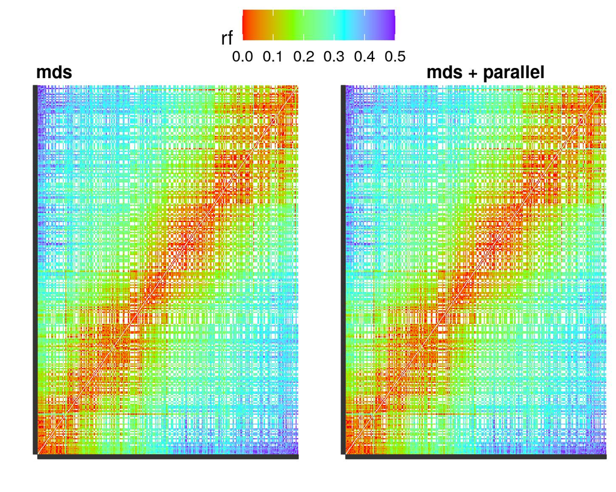

```r
# Without parallelization ok
map_mds <- mds_onemap(input.seq = seq_all)

# With parallelization
map_mds_par <- mds_onemap(input.seq = seq_all,
                          phase_cores = 4,
                          size = batch_size,
                          overlap = 30)
```

## Speed up map estimation for an arbitrary order (map function)

Because we simulate this dataset we know the correct order. We can use `map_overlapping_batches` to estimate genetic distance in this case. This is equivalent to `map`, but with parallelized process.

Similarly with `map`, using argument `rm_unlinked = TRUE` the function will return a vector with marker numbers without the problematic marker. To repeat the analysis removing automatically all problematic markers use `map_avoid_unlinked`:

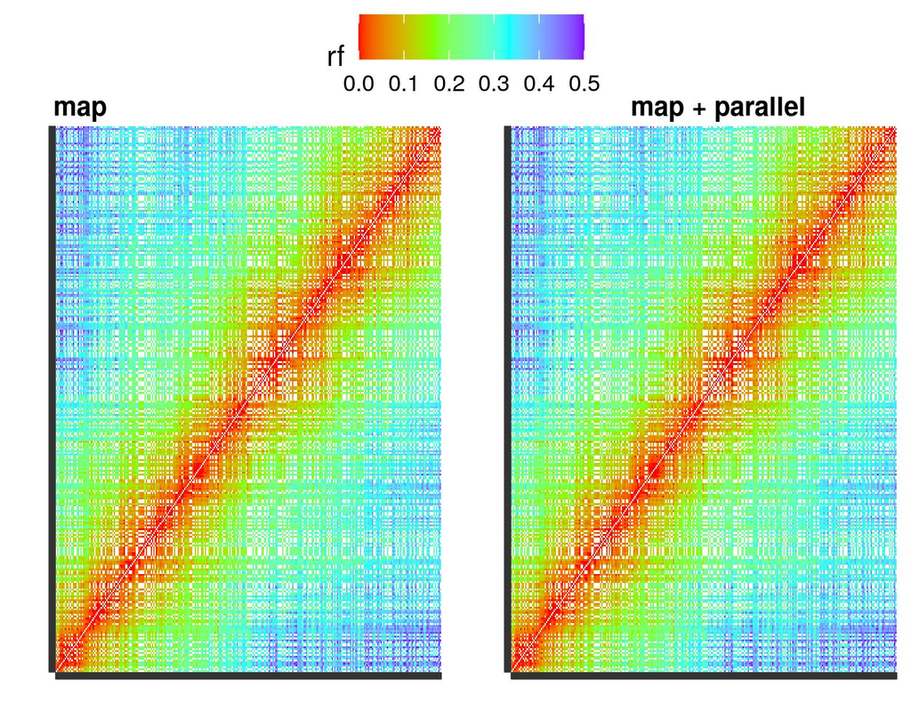

```r
# Without parallelization
batch_map <- map_avoid_unlinked(input.seq = seq_all)

# With parallelization
batch_map_par <- map_avoid_unlinked(input.seq = seq_all,
                                    size = batch_size,
                                    phase_cores = 4,
                                    overlap = 30)
```

As you can see in above maps, heuristic ordering algorithm do not return an optimal order result, mostly if you don’t have many individuals in your population. Because of the erroneous order, generated map size are not close to the simulated size (100 cM) and their heapmaps don’t present the expected color pattern. Two of them get close to the color pattern, they are the ug and the MDS method. They present good global ordering but not local. If you have a reference genome, you can use its position information to rearrange local ordering.

# Export estimated parents haplotypes (new!)

In older version, users could only access the estimated linkage phase observing the print in the console:

```r
CHR3_final
```

```
##
## Printing map:
##
## Markers           Position           Parent 1       Parent 2
##
## 27 M27                0.00           b |  | o       a |  | a
## 16 M16               11.76           a |  | a       b |  | o
## 20 M20               22.94           a |  | b       c |  | d
##  4 M4                35.71           a |  | o       o |  | b
## 21 M21               49.41           o |  | o       a |  | b
## 23 M23               55.24           a |  | o       a |  | o
## 48 SNP21             67.50           a |  | b       a |  | a
##  9 M9                74.02           a |  | b       a |  | a
## 46 SNP18             80.43           a |  | b       a |  | a
## 45 SNP17             95.40           a |  | b       a |  | a
## 47 SNP20            119.95           a |  | b       a |  | a
## 50 SNP23            158.43           a |  | b       b |  | a
## 24 M24              163.43           a |  | b       b |  | a
## 49 SNP22            166.72           a |  | b       b |  | a
## 52 SNP25            171.62           a |  | b       b |  | a
## 51 SNP24            182.56           a |  | b       b |  | a
##
## 16 markers            log-likelihood: -811.5279
```

Now, you can export this information into a data.frame using:

```r
(parents_haplot <- parents_haplotypes(CHR3_final))
```

```
##       group mk.number mk.names     dist P1_1 P1_2 P2_1 P2_2
## 1 Group - 1        27      M27  0.00000    b    o    a    a
## 2 Group - 1        16      M16 11.75801    a    a    b    o
## 3 Group - 1        20      M20 22.93778    a    b    c    d
## 4 Group - 1         4       M4 35.70756    a    o    o    b
## 5 Group - 1        21      M21 49.40658    o    o    a    b
## 6 Group - 1        23      M23 55.24441    a    o    a    o
## 7 Group - 1        48    SNP21 67.49802    a    b    a    a
## 8 Group - 1         9       M9 74.02260    a    b    a    a
## 9 Group - 1        46    SNP18 80.43325    a    b    a    a
##  [ reached 'max' / getOption("max.print") -- omitted 7 rows ]
```

```r
write.table(parents_haplot, "parents_haplot.txt")
```

The data.frame contains: group ID (group), marker number (mk.number) and names (mk.names), position in centimorgan (dist) and parents haplotypes (P1_1, P1_2, P2_1, P2_2).

You can also obtain a data.frame with a list of sequences and personalize the group names:

```r
parents_haplotypes(CHR2_final,CHR3_final, group_names=c("CHR2","CHR3"))
```

```
##   group mk.number mk.names     dist P1_1 P1_2 P2_1 P2_2
## 1  CHR2        43    SNP14  0.00000    a    b    a    a
## 2  CHR2        22      M22 13.50513    a    b    a    a
## 3  CHR2         7       M7 23.08429    a    a    a    b
## 4  CHR2        18      M18 64.51343    a    b    c    d
## 5  CHR2         8       M8 70.19895    b    a    b    a
## 6  CHR2        13      M13 72.86392    a    o    a    o
## 7  CHR2        44    SNP16 78.74250    b    a    b    a
## 8  CHR3        27      M27  0.00000    b    o    a    a
## 9  CHR3        16      M16 11.75801    a    a    b    o
##  [ reached 'max' / getOption("max.print") -- omitted 14 rows ]
```

# Export estimated progeny haplotypes (new!)

Function `progeny_haplotypes` generates a data.frame with progeny phased haplotypes estimated by `OneMap` HMM. For progeny, the HMM results in probabilities for each possible genotypes, than the generated data.frame contains all possible genotypes. If `most_likely = TRUE` the most likely genotype receveis 1 and the rest 0 (if there are two most likely both receive 0.5), if `most_likely = FALSE` genotypes probabilities will be according with the HMM results. You can choose which individual to be evaluated in `ind`. The data.frame is composed by the information: individual (ind) and group (grp) ID, position in centimorgan (pos), progeny homologs (homologs) and from each parent the allele came (parents).

```r
(progeny_haplot <- progeny_haplotypes(CHR2_final, most_likely = TRUE, ind = c(1,2), group_names = "CHR2_final"))
```

```
##    ind        grp      pos prob homologs parents
## 1    1 CHR2_final  0.00000  0.0       H1      P1
## 2    1 CHR2_final 13.50513  0.0       H1      P1
## 3    1 CHR2_final 23.08429  0.0       H1      P1
## 4    1 CHR2_final 64.51343  1.0       H1      P1
## 5    1 CHR2_final 70.19895  1.0       H1      P1
## 6    1 CHR2_final 72.86392  1.0       H1      P1
## 7    1 CHR2_final 78.74250  0.5       H1      P1
## 8    2 CHR2_final  0.00000  1.0       H1      P1
## 9    2 CHR2_final 13.50513  1.0       H1      P1
## 10   2 CHR2_final 23.08429  1.0       H1      P1
## 11   2 CHR2_final 64.51343  1.0       H1      P1
## 12   2 CHR2_final 70.19895  1.0       H1      P1
##  [ reached 'max' / getOption("max.print") -- omitted 44 rows ]
```

You can also have a view of progeny estimated haplotypes using `plot`. It shows which markers came from each parents homologues. `position` argument defines if haplotypes will be plotted by homologs (`stack`) or alleles (`split`). `split` option is a good way to better view the likelihoods of each alleles.

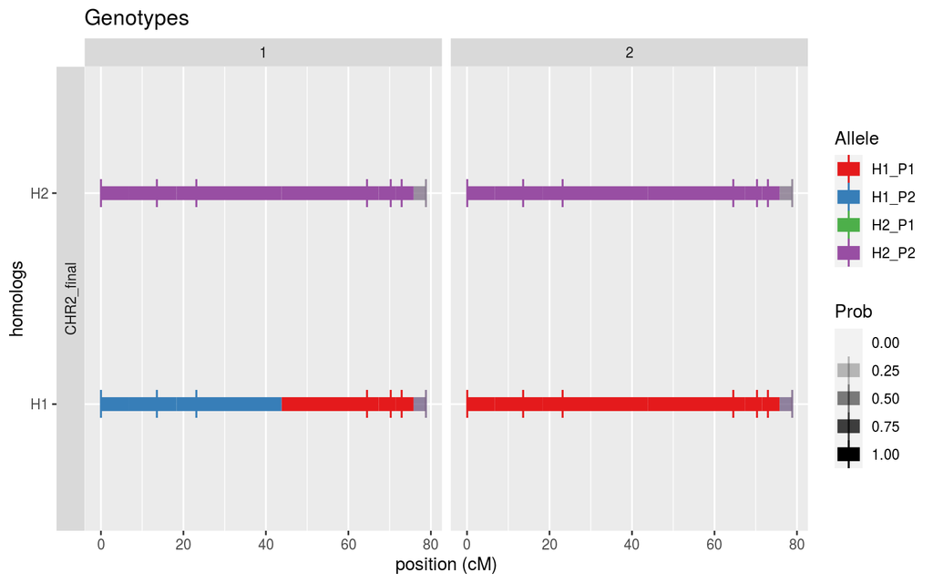

```r
plot(progeny_haplot, position = "stack")
```

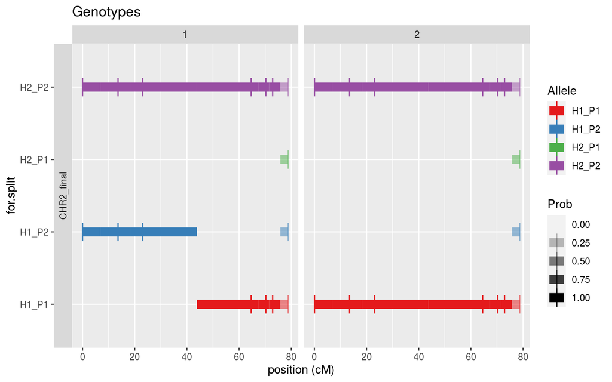

```r
plot(progeny_haplot, position = "split")
```

## Comparing estimated and simulated haplotypes

The simulations here included are very useful to test our algorithms efficiency, we made them available in case to be useful for other purposes. Using functions `run_pedsim`, `pedsim2vcf` with argument phased `TRUE` we can convert the phased VCF using `vcf2progeny_haplotypes`, which keeps the original haplotype. With that we can compare the haplotypes simulated and the ones estimated by the onemap approach.

```r
pedsim2vcf(inputfile = system.file("extdata/sim_cod_out_genotypes.dat", package = "onemap"),
           map.file = system.file("extdata/mapfile_out.txt", package = "onemap"),
           chrom.file = system.file("extdata/sim_out.chrom", package = "onemap"),
           out.file = "simu_out_phased.vcf",
           miss.perc = 0,
           counts = FALSE,
           chr.mb = 10,
           pos="cM",
           chr=NULL,
           phase = TRUE)
```

Now, we can convert the phased VCF to onemap_progeny_haplotypes object using function `vcf2progeny_haplotypes`. The position, the group names and individuals id will be according with the ones contained in VCF file. This function can take some time to run if you select too many individuals or groups.

```r
vcfR.object <- read.vcfR("simu_out_phased.vcf")
```

[output not shown]

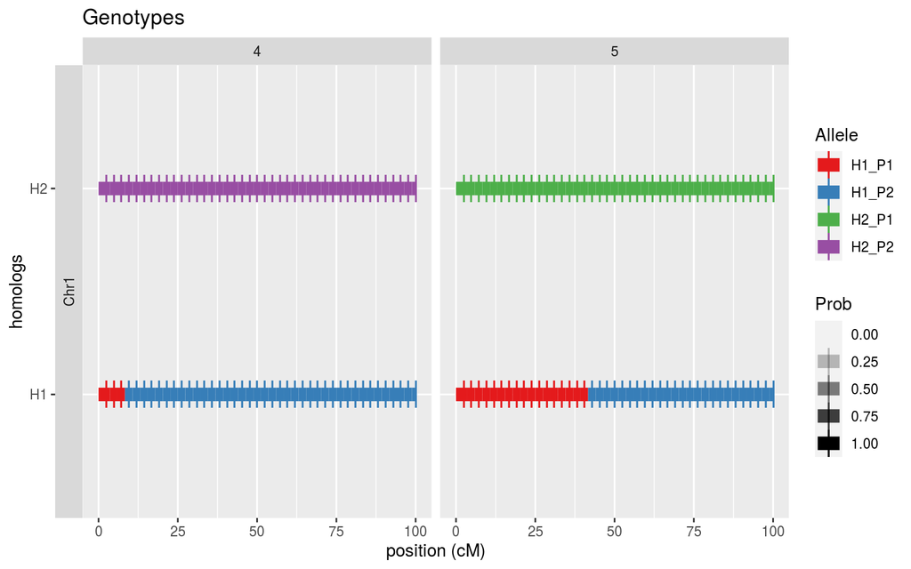

```r
progeny_dat <- vcf2progeny_haplotypes(vcfR.object = vcfR.object, ind.id = c("F1_004", "F1_005"), group_names = "Chr1", parent1 = "P1", parent2 = "P2", crosstype = "outcross")
plot(progeny_dat)
```

This is the simulated dataset. If OneMap algorithm could get all information needed, it could reproduce this haplotypes exactly how they were in simulated data. Let’s see how OneMap estimate these haplotypes:

```r
onemap_test <- onemap_read_vcfR(vcfR.object = vcfR.object, cross = "outcross", parent1 = "P1", parent2 = "P2", only_biallelic = FALSE)

onemap_test # Just to remember of which dataset we are talking about
```

```
##   This is an object of class 'onemap'
##     Type of cross:      outcross
##     No. individuals:    200
##     No. markers:        42
##     CHROM information:  yes
##     POS information:    yes
##     Percent genotyped:  100
##
##     Segregation types:
##                 A.1 -->  6
##                 A.2 -->  6
##                B3.7 -->  6
##               D1.10 -->  6
##                D1.9 -->  6
##               D2.14 -->  6
##               D2.15 -->  6
##
##     No. traits:         0
```

```r
twopts <- rf_2pts(onemap_test)
```

```
## Computing 861 recombination fractions ...
```

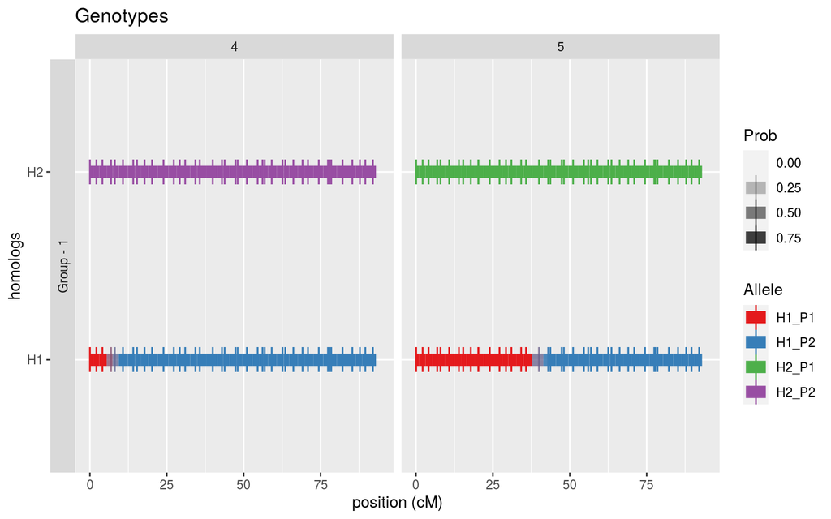

```r
seq1 <- make_seq(twopts, "all")
map_test <- map(seq1)
progeny_est <- progeny_haplotypes(map_test, ind = c(4,5), most_likely = FALSE)
plot(progeny_est)
```

See that, besides markers are not in their exactly position, the recombination break points are the same as the ones simulated. The marker position could only be exactly the same as the ones simulated if we have a very big (or maybe infinite) population size, but here we have only 200 individuals, but this is not a problem once we could reproduce the haplotypes.

# References

Buetow, K. H., Chakravarti, A. Multipoint gene mapping using seriation. I. General methods. *American Journal of Human Genetics* 41, 180-188, 1987.

Doerge, R.W. Constructing genetic maps by rapid chain delineation. *Journal of Agricultural Genomics* 2, 1996.

Mollinari, M., Margarido, G. R. A., Vencovsky, R. and Garcia, A. A. F. Evaluation of algorithms used to order markers on genetics maps. *Heredity* 103, 494-502, 2009.

Schiffthaler, B., Bernhardsson, C., Ingvarsson, P. K., & Street, N. R. BatchMap: A parallel implementation of the OneMap R package for fast computation of F1 linkage maps in outcrossing species. *PLoS ONE*, 12(12), 1–12, 2017.

Tan, Y., Fu, Y. A novel method for estimating linkage maps. *Genetics* 173, 2383-2390, 2006.

Van Os H, Stam P, Visser R.G.F., Van Eck H.J. RECORD: a novel method for ordering loci on a genetic linkage map. *Theor Appl Genet* 112, 30-40, 2005.

Voorrips, R.E. MapChart: software for the graphical presentation of linkage maps and QTLs. *Journal of Heredity* 93, 77-78, 2002.

Voorrips, R. E., Maliepaard, C. A. The simulation of meiosis in diploid and tetraploid organisms using various genetic models. *BMC Bioinformatics*, 13(1), 248, 2012.

Wu, R., Ma, C.X., Painter, I. and Zeng, Z.-B. Simultaneous maximum likelihood estimation of linkage and linkage phases in outcrossing species. *Theoretical Population Biology* 61, 349-363, 2002a.

Wu, R., Ma, C.-X., Wu, S. S. and Zeng, Z.-B. Linkage mapping of sex-specific differences. *Genetical Research* 79, 85-96, 2002b.

[Statistical Genetics Lab](http://statgen.esalq.usp.br)  
Department of Genetics  
Luiz de Queiroz College of Agriculture  
University of São Paulo

2020-07-19